# Public health and Economic Impact of Severe Weather Events in the US

## Synopsis

The objective of this publication is to do an analysis on the NOAA Storm Database (a weather events information dataset) and identify the most impacting weather events to the public health and to the economy of the US so that authorities can properly plan an assign resources to prepare for these type of events. To this extend the analysis will take into consideration fatalities and injuries as well as crop and property damage from each event.

## Data processing

### R Libraries to be used

```r
library(dplyr)
library(ggplot2)
library(lubridate)
library(knitr)
```

### Reading the data

This is based on NOAA Storm Database Analysis coming in the form of a bz2 file at this link [*NOAA Storm Data*](https://d396qusza40orc.cloudfront.net/repdata%2Fdata%2FStormData.csv.bz2) located on coursera Assignment Page. Additional sources include a [Documentation Reference](https://d396qusza40orc.cloudfront.net/repdata%2Fpeer2_doc%2Fpd01016005curr.pdf) for this data from National Weather Service and National Climatic Data Center Storm Events [FAQ](https://d396qusza40orc.cloudfront.net/repdata%2Fpeer2_doc%2FNCDC%20Storm%20Events-FAQ%20Page.pdf) for same data.

To use the data, initially we are going to strip white spaces and modify how to identify NA values by using “” as a valid NA.

```r
bzfileUrl <- "https://d396qusza40orc.cloudfront.net/repdata%2Fdata%2FStormData.csv.bz2"
download.file(bzfileUrl, destfile = paste0(getwd(), "/StormData.csv.bz2"), method = "curl")
stormdata <- read.table("StormData.csv.bz2", header = TRUE, sep = ",", strip.white = TRUE, stringsAsFactors = FALSE, na.strings = c("NA",""))
```

After loading the data, we end up with a total of **902297** observations of weather event/reports (look Apendixes and Notes at the end to check data structure).

### Data quality check

#### The STATE geographical element

Is worth to highlight that the STATE variable has not just US state but US territories and maritime zones up to a total of **72**

```r
unique(stormdata$STATE)
```

```
##  [1] "AL" "AZ" "AR" "CA" "CO" "CT" "DE" "DC" "FL" "GA" "HI" "ID" "IL" "IN"
## [15] "IA" "KS" "KY" "LA" "ME" "MD" "MA" "MI" "MN" "MS" "MO" "MT" "NE" "NV"
## [29] "NH" "NJ" "NM" "NY" "NC" "ND" "OH" "OK" "OR" "PA" "RI" "SC" "SD" "TN"
## [43] "TX" "UT" "VT" "VA" "WA" "WV" "WI" "WY" "PR" "AK" "ST" "AS" "GU" "MH"
## [57] "VI" "AM" "LC" "PH" "GM" "PZ" "AN" "LH" "LM" "LE" "LS" "SL" "LO" "PM"
## [71] "PK" "XX"
```

#### The EVENT TYPE classification

Upon inspection of the variable we notice that is of character type and that it has both lowercase and upper case text, also it has several typos on the event description spelling; we will address theese issues by taking a copy to a new variable EVENT_TYPE using only uppercase values and then we will fix the common typos detected including some inner white space reduction:

```r
stormdata$EVTYPE <- toupper(stormdata$EVTYPE)
stormdata$EVENT_TYPE <- stormdata$EVTYPE
stormdata$EVENT_TYPE <- trimws(stormdata$EVENT_TYPE)
stormdata$EVENT_TYPE <- gsub("  "," ",stormdata$EVENT_TYPE)
stormdata$EVENT_TYPE <- gsub("  "," ",stormdata$EVENT_TYPE)
stormdata$EVENT_TYPE <- gsub("  "," ",stormdata$EVENT_TYPE)
stormdata$EVENT_TYPE <- gsub("AVALANCE","AVALANCHE",stormdata$EVENT_TYPE)
stormdata$EVENT_TYPE <- gsub("EROSIN","EROSION",stormdata$EVENT_TYPE)
stormdata$EVENT_TYPE <- gsub("EROSIN","EROSION",stormdata$EVENT_TYPE)
stormdata$EVENT_TYPE <- gsub("BRUSH FIRES","BRUSH FIRE",stormdata$EVENT_TYPE)
stormdata$EVENT_TYPE <- gsub("MIRCOBURST","MICROBURST",stormdata$EVENT_TYPE)
stormdata$EVENT_TYPE <- gsub("MICOBURST","MICROBURST",stormdata$EVENT_TYPE)
stormdata$EVENT_TYPE <- gsub("DUSTSTORM","DUST STORM",stormdata$EVENT_TYPE)
stormdata$EVENT_TYPE <- gsub("FLOOODING","FLOODING",stormdata$EVENT_TYPE)
stormdata$EVENT_TYPE <- gsub("FLD","FLOODING",stormdata$EVENT_TYPE)
stormdata$EVENT_TYPE <- gsub("FLOODIN\\>","FLOODING",stormdata$EVENT_TYPE)
stormdata$EVENT_TYPE <- gsub("FLASHFLOOD","FLASH FLOOD",stormdata$EVENT_TYPE)
stormdata$EVENT_TYPE <- gsub("FLASH/FLOOD","FLASH FLOOD",stormdata$EVENT_TYPE)
stormdata$EVENT_TYPE <- gsub("HEATBURST","HEAT BURST",stormdata$EVENT_TYPE)
stormdata$EVENT_TYPE <- gsub("PRECIPATATION","PRECIPITATION",stormdata$EVENT_TYPE)
stormdata$EVENT_TYPE <- gsub("ANDBLOWING","AND BLOWING",stormdata$EVENT_TYPE)
stormdata$EVENT_TYPE <- gsub("LIGNTNING","LIGHTNING",stormdata$EVENT_TYPE)
stormdata$EVENT_TYPE <- gsub("THUDERSTORM|THUNDEERSTORM|THUNDERESTORM|THUNDERSTORMW|THUNDERSTROM|THUNDESTORM|THUNERSTORM|TUNDERSTORM|TSTM","THUNDERSTORM",
                             stormdata$EVENT_TYPE)
stormdata$EVENT_TYPE <- gsub("TORNDAO|TORNADOES","TORNADO",stormdata$EVENT_TYPE)
stormdata$EVENT_TYPE <- gsub("WAYTERSPOUT","WATERSPOUT",stormdata$EVENT_TYPE)
stormdata$EVENT_TYPE <- gsub("WND","WIND",stormdata$EVENT_TYPE)
stormdata$EVENT_TYPE <- gsub("WINTRY","WINTERY",stormdata$EVENT_TYPE)
stormdata$EVENT_TYPE <- gsub("VOG","FOG",stormdata$EVENT_TYPE)
```

Finally, to properly asses the events impact, we must “reduce” the number of the diverse 800+ values to a more manegeable number closer to the 48 defined NOAA values. This will be achieved by creating a new column EVENT_CLASS that will be matched as best as possible to one of the 48 NOAA values (some NOAA values will be clashed together), if no possible match is found a “NON STANDARD” value will be assigned.

```r
stormdata <- stormdata %>%
                mutate(EVENT_CLASS =
                    case_when(
                        regexpr(glob2rx("*LOW TIDE*"),EVENT_TYPE) !=-1 ~ "ASTRONOMICAL LOW TIDE",
                        regexpr(glob2rx("*HIGH TIDE*"),EVENT_TYPE) !=-1 ~ "ASTRONOMICAL HIGH TIDE",
                        regexpr(glob2rx("*AVALANCHE*"),EVENT_TYPE) !=-1 ~ "AVALANCHE",
                        regexpr(glob2rx("*COASTAL FLOOD*"),EVENT_TYPE) !=-1 ~ "COASTAL FLOOD",
                        (regexpr(glob2rx("*WIND CHILL*"),EVENT_TYPE) !=-1)|(regexpr(glob2rx("*COLD*"),EVENT_TYPE) !=-1) ~ "COLD/WIND CHILL (EXTREME)",
                        regexpr(glob2rx("*DENSE SMOKE*"),EVENT_TYPE) !=-1 ~ "DENSE SMOKE",
                        regexpr(glob2rx("*DENSE FOG*|FOG"),EVENT_TYPE) !=-1 ~ "FOG|DENSE FOG",
                        (regexpr(glob2rx("*DUST DEVIL*"),EVENT_TYPE) !=-1)|(regexpr(glob2rx("*DUST STORM*"),EVENT_TYPE) !=-1) ~ "DUST DEVIL/STORM",
                        regexpr(glob2rx("*HEAT*"),EVENT_TYPE) !=-1 ~ "HEAT/(EXCESSIVE HEAT)",
                        regexpr(glob2rx("*FLOOD*|*SURGE*"),EVENT_TYPE) !=-1 ~ "FLOOD,FLASH FLOOD,SURGE)",
                        regexpr(glob2rx("*FREEZ*"),EVENT_TYPE) !=-1 ~ "FREEZING|FROST",
                        regexpr(glob2rx("*FUNNEL*"),EVENT_TYPE) !=-1 ~ "FUNNEL CLOUD",
                        regexpr(glob2rx("*HAIL*"),EVENT_TYPE) !=-1 ~ "HAIL",
                        regexpr(glob2rx("*RAIN*|*PRECIPI*"),EVENT_TYPE) !=-1 ~ "RAIN (HEAVY)",
                        regexpr(glob2rx("*SNOW*|*BLIZZ*"),EVENT_TYPE) !=-1 ~ "SNOW (HEAVY)|BLIZZARD",
                        regexpr(glob2rx("*SURF*|HI*WAV*|*SEAS"),EVENT_TYPE) !=-1 ~ "SURF/SEAS (HEAVY/HIGH)",
                        (regexpr(glob2rx("*HURRI*"),EVENT_TYPE) !=-1)|(regexpr(glob2rx("*TYPHO*"),EVENT_TYPE) !=-1) ~ "HURRICANE/TYPHOON",
                        regexpr(glob2rx("*ICE*|*GLAZE*|*ICY*|*LOW*TEMP*|*HYP*|*FROS*"),EVENT_TYPE) !=-1 ~ "ICE|GLAZE EVENT",
                        regexpr(glob2rx("*LIGHTNING*"),EVENT_TYPE) !=-1 ~ "LIGHTNING",
                        regexpr(glob2rx("*G*WIND*|*WIND*|*MICRO*"),EVENT_TYPE) !=-1 ~ "WIND EVENT (MICROBURST)",
                        regexpr(glob2rx("*HIGH WIND*"),EVENT_TYPE) !=-1 ~ "HIGH WIND",
                        regexpr(glob2rx("*MARINE*WIND*"),EVENT_TYPE) !=-1 ~ "MARINE WIND EVENT",
                        regexpr(glob2rx("*RIP*"),EVENT_TYPE) !=-1 ~ "RIP CURRENT",
                        regexpr(glob2rx("*SEICHE*"),EVENT_TYPE) !=-1 ~ "SEICHE",
                        regexpr(glob2rx("*SLEET*"),EVENT_TYPE) !=-1 ~ "SLEET",
                        regexpr(glob2rx("*STORM*TIDE*"),EVENT_TYPE) !=-1 ~ "STORM TIDE",
                        regexpr(glob2rx("*STRONG*WIND*"),EVENT_TYPE) !=-1 ~ "STRONG WIND",
                        (regexpr(glob2rx("*THUNDERSTOR*"),EVENT_TYPE) !=-1)|(regexpr(glob2rx("*GUSTNA*|*DOWNBU*"),EVENT_TYPE) !=-1) ~ "THUNDERSTORM EVENTS",
                        (regexpr(glob2rx("*TORNADO*"),EVENT_TYPE) !=-1)|(regexpr(glob2rx("*WATERSP*|*LANDSPOUTS*"),EVENT_TYPE) !=-1) ~ "TORNADO",
                        regexpr(glob2rx("*TROPI*"),EVENT_TYPE) !=-1 ~ "TROPICAL STORM/DEPRESSION",
                        regexpr(glob2rx("C*STORM*"),EVENT_TYPE) !=-1 ~ "COASTAL STORM",
                        regexpr(glob2rx("*TSUNAM*"),EVENT_TYPE) !=-1 ~ "TSUNAMI",
                        regexpr(glob2rx("*SLIDE*"),EVENT_TYPE) !=-1 ~ "LANDSLIDE-MUDSLIDE",
                        regexpr(glob2rx("*VOLCA*"),EVENT_TYPE) !=-1 ~ "VOLCANIC EVENT",
                        regexpr(glob2rx("*WILD*FIRE*|*FORE*FIRE*"),EVENT_TYPE) !=-1 ~ "WILD/FOREST FIRE",
                        regexpr(glob2rx("*WET*"),EVENT_TYPE) !=-1 ~ "WET/WETNESS EVENT",
                        regexpr(glob2rx("*WINTER*"),EVENT_TYPE) !=-1 ~ "WINTER STORM/WEATHER",
                        regexpr(glob2rx("*DROUGHT*"),EVENT_TYPE) !=-1 ~ "DROUGHT",
                        TRUE ~ "NON STANDARD")
                )
```

After the previous artifacts and typos removal, plus the simplified classification of EVENTS we end up with the following number of event classes and number of observations where no class could be assigned, note that this will be **0.0884%** of the total observations.

```r
NROW(unique(stormdata$EVENT_CLASS))
```

```
## [1] 35
```

```r
sort(unique(stormdata$EVENT_CLASS))
```

```
##  [1] "ASTRONOMICAL HIGH TIDE"    "ASTRONOMICAL LOW TIDE"
##  [3] "AVALANCHE"                 "COASTAL FLOOD"
##  [5] "COASTAL STORM"             "COLD/WIND CHILL (EXTREME)"
##  [7] "DENSE SMOKE"               "DROUGHT"
##  [9] "DUST DEVIL/STORM"          "FLOOD,FLASH FLOOD,SURGE)"
## [11] "FOG|DENSE FOG"             "FREEZING|FROST"
## [13] "FUNNEL CLOUD"              "HAIL"
## [15] "HEAT/(EXCESSIVE HEAT)"     "HURRICANE/TYPHOON"
## [17] "ICE|GLAZE EVENT"           "LANDSLIDE-MUDSLIDE"
## [19] "LIGHTNING"                 "NON STANDARD"
## [21] "RAIN (HEAVY)"              "RIP CURRENT"
## [23] "SEICHE"                    "SLEET"
## [25] "SNOW (HEAVY)|BLIZZARD"     "SURF/SEAS (HEAVY/HIGH)"
## [27] "THUNDERSTORM EVENTS"       "TORNADO"
## [29] "TROPICAL STORM/DEPRESSION" "TSUNAMI"
## [31] "VOLCANIC EVENT"            "WET/WETNESS EVENT"
## [33] "WILD/FOREST FIRE"          "WIND EVENT (MICROBURST)"
## [35] "WINTER STORM/WEATHER"
```

```r
NROW(stormdata[stormdata$EVENT_CLASS=="NON STANDARD",])
```

```
## [1] 798
```

#### The date of event Begin

Regarding dates and time zones, although dates are properly formated time is not so a colon is added to the text and a new variable BEGINDATETIME is created.

```r
stormdata <- stormdata %>%
                mutate(BEGINDATETIME =
                        mdy_hms(stormdata$BGN_DATE) +
                        hm(paste0(substr(stormdata$BGN_TIME,1,2),":",substr(stormdata$BGN_TIME,3,4))))
```

Rgarding Time Zones they are not actually part of the event begin date, and also do not follow exactly the standards. As for this analysis we won’ use the time zone as a critical factor, but for propper time management a fix is needed.

```r
stormdata$TIME_ZONE <- toupper(stormdata$TIME_ZONE)
unique(stormdata$TIME_ZONE)
```

```
##  [1] "CST" "EST" "PST" "MST" "CDT" "PDT" "EDT" "UNK" "HST" "GMT" "MDT"
## [12] "AST" "ADT" "CSC" "SCT" "ESY" "UTC" "SST" "AKS" "GST"
```

#### Identifyig and preparing the damage calculation variables

As a precaution, since current data set variables description is not clear and not provided, I will do refer to (current version of NOAA storm database)[http://www1.ncdc.noaa.gov/pub/data/swdi/stormevents/csvfiles/Storm-Data-Export-Format.docx] to handle the definition of our variables of interest.

According to documentation, there are 2 variables that identify health related damage **FATALITIES** and **INJURIES** and both provide only the direct cases. To simplify we will add one variable **VICTIMS** as the sum of both.

```r
stormdata <- stormdata %>%  mutate( VICTIMS = FATALITIES + INJURIES)
```

In the case of the economic damage we will refer to variables **CROPDMG/CROPDMGEXP** and **PRODMG/PROPDMGEXP**. The xDMG variables have a value that indicate the estimation, while xDMGEXP represents a multiplier USD factor. Bellow we will show current unque values, once we set all up to UPPER CASE to standardize, and also the distribution of observations per unique value:

```r
stormdata$PROPDMGEXP <- toupper(stormdata$PROPDMGEXP)
unique(stormdata$PROPDMGEXP)
```

```
##  [1] "K" "M" NA  "B" "+" "0" "5" "6" "?" "4" "2" "3" "H" "7" "-" "1" "8"
```

```r
kable(stormdata %>% group_by(PROPDMGEXP) %>% summarise(num_obs=n(), simple_dmg_sum = sum(PROPDMG)),format = "html") %>% kableExtra::kable_styling(bootstrap_options = c("striped", "hover", "condensed"),full_width = F)
```

```r
stormdata$CROPDMGEXP <- toupper(stormdata$CROPDMGEXP)
unique(stormdata$CROPDMGEXP)
```

```
## [1] NA  "M" "K" "B" "?" "0" "2"
```

```r
kable(stormdata %>% group_by(CROPDMGEXP) %>% summarise(num_obs = n(), simple_dmg_sum = sum(CROPDMG)),format = "html") %>% kableExtra::kable_styling(bootstrap_options = c("striped", "hover", "condensed"),full_width = F)
```

| CROPDMGEXP | num_obs | simple_dmg_sum |
| --- | --- | --- |
| ? | 7 | 0.00 |
| 0 | 19 | 260.00 |
| 2 | 1 | 0.00 |
| B | 9 | 13.61 |
| K | 281853 | 1343391.91 |
| M | 1995 | 34150.80 |
| NA | 618413 | 11.00 |

For crop damage we will use the rul eof multiplying CROPDMG value by 1.000.000.000 = “B”, 1.000.000 = “M” ans 1.000 = “K”, remaining CROPDMGEXP values will be taken as “zero”, including N.A. since there are only 3 NA CROPDMGEXP with CROPDMG greater thatn zero.

once calculation rules are defined we will and *PROPDMGVAL*, *CROPDMGVAL* and *ECONDMGVAL* all in USD following above rules, ECONDMGVAL will be the sum of PROPDMGVAL and CROPDMGVAL.

```r
stormdata <- stormdata %>%
                mutate(
                    PROPDMGVAL = PROPDMG * case_when(PROPDMGEXP == "M" ~ 1000000,
                                                     PROPDMGEXP == "B" ~ 1000000000,
                                                     PROPDMGEXP == "K" ~ 1000,
                                                     PROPDMGEXP == "H" ~ 100,
                                                     TRUE ~ 0),
                    CROPDMGVAL = CROPDMG * case_when(CROPDMGEXP == "M" ~ 1000000,
                                                     CROPDMGEXP == "B" ~ 1000000000,
                                                     CROPDMGEXP == "K" ~ 1000,
                                                     TRUE ~ 0),
                    ECONDMGVAL = PROPDMGVAL + CROPDMGVAL
                    )
```

## Results

After data adjustment, bellow you can find the simplified list of what is the health and the economic impact of weather events across US and terriories

### Health Impact, 10 highest contributors

Based on fatalities and injuries count, bellow is graph that shows the 10 most impacting type of events.

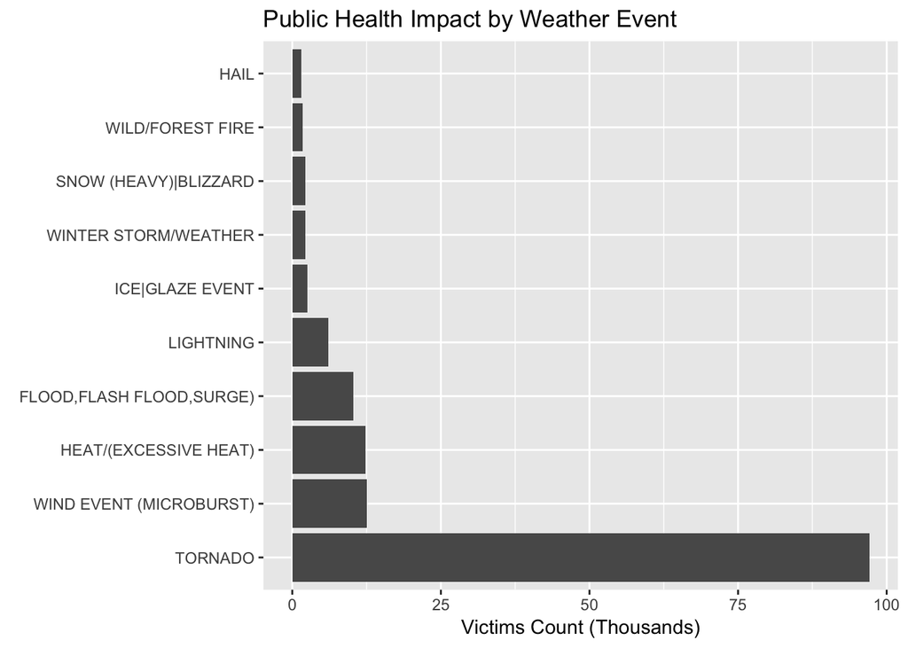

```r
health_impact_data <- head(stormdata %>% group_by(EVENT_CLASS) %>%
                               summarise(healthimpact = sum(VICTIMS)) %>%
                               arrange(desc(healthimpact)),
                           10)

ggplot(health_impact_data, aes(x=EVENT_CLASS, y=healthimpact)) +
        geom_col() + coord_flip() +
        labs(title = "Public Health Impact by Weather Event", x=element_blank(), y="Victims Count (Thousands)")  +
        scale_y_continuous(labels = scales::comma_format(scale=1/1000)) +
        scale_x_discrete(limits = health_impact_data$EVENT_CLASS)
```

### Economic Impact - 10 Highest contributors

Based on property and crop combined damage value, bellow is graph that shows the 10 most impacting type of events.

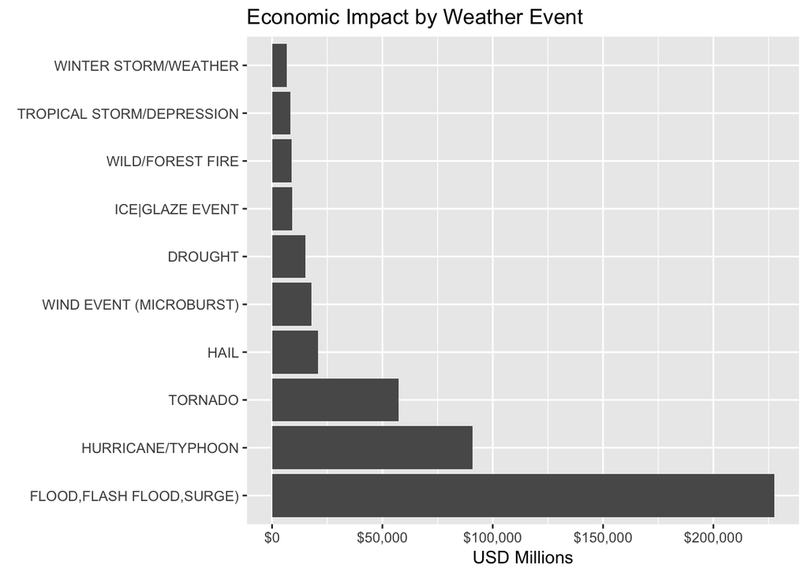

```r
econom_impact_data <- head(stormdata %>% group_by(EVENT_CLASS) %>%
                               summarise(economicimpact = sum(ECONDMGVAL)) %>%
                               arrange(desc(economicimpact)),
                           10)

ggplot(econom_impact_data, aes(x=EVENT_CLASS, y=economicimpact)) +
        geom_col() + coord_flip() +
        labs(title = "Economic Impact by Weather Event", x=element_blank(), y="USD Millions")  +
        scale_y_continuous(labels = scales::dollar_format(scale=1/1000000)) +
        scale_x_discrete(limits = econom_impact_data$EVENT_CLASS)
```

## Apendixes and Notes

### Storm Data Structure

```r
str(stormdata)
```

```
## 'data.frame':    902297 obs. of  44 variables:
##  $ STATE__      : num  1 1 1 1 1 1 1 1 1 1 ...
##  $ BGN_DATE     : chr  "4/18/1950 0:00:00" "4/18/1950 0:00:00" "2/20/1951 0:00:00" "6/8/1951 0:00:00" ...
##  $ BGN_TIME     : chr  "0130" "0145" "1600" "0900" ...
##  $ TIME_ZONE    : chr  "CST" "CST" "CST" "CST" ...
##  $ COUNTY       : num  97 3 57 89 43 77 9 123 125 57 ...
##  $ COUNTYNAME   : chr  "MOBILE" "BALDWIN" "FAYETTE" "MADISON" ...
##  $ STATE        : chr  "AL" "AL" "AL" "AL" ...
##  $ EVTYPE       : chr  "TORNADO" "TORNADO" "TORNADO" "TORNADO" ...
##  $ BGN_RANGE    : num  0 0 0 0 0 0 0 0 0 0 ...
##  $ BGN_AZI      : chr  NA NA NA NA ...
##  $ BGN_LOCATI   : chr  NA NA NA NA ...
##  $ END_DATE     : chr  NA NA NA NA ...
##  $ END_TIME     : chr  NA NA NA NA ...
##  $ COUNTY_END   : num  0 0 0 0 0 0 0 0 0 0 ...
```

[output cut: 30 more lines]

### Original 898 Event Types with typos and spelling issues

```r
sort(unique(stormdata$EVTYPE))
```

```
##   [1] "   HIGH SURF ADVISORY"          " COASTAL FLOOD"
##   [3] " FLASH FLOOD"                   " LIGHTNING"
##   [5] " TSTM WIND"                     " TSTM WIND (G45)"
##   [7] " WATERSPOUT"                    " WIND"
##   [9] "?"                              "ABNORMAL WARMTH"
##  [11] "ABNORMALLY DRY"                 "ABNORMALLY WET"
##  [13] "ACCUMULATED SNOWFALL"           "AGRICULTURAL FREEZE"
##  [15] "APACHE COUNTY"                  "ASTRONOMICAL HIGH TIDE"
##  [17] "ASTRONOMICAL LOW TIDE"          "AVALANCE"
##  [19] "AVALANCHE"                      "BEACH EROSIN"
##  [21] "BEACH EROSION"                  "BEACH EROSION/COASTAL FLOOD"
##  [23] "BEACH FLOOD"                    "BELOW NORMAL PRECIPITATION"
##  [25] "BITTER WIND CHILL"              "BITTER WIND CHILL TEMPERATURES"
##  [27] "BLACK ICE"                      "BLIZZARD"
##  [29] "BLIZZARD AND EXTREME WIND CHIL" "BLIZZARD AND HEAVY SNOW"
```

[output cut: 434 more lines]

### Unexisting PROPDMGEXP with positive PROPDMG

```r
kable(stormdata %>% filter(is.na(PROPDMGEXP) & PROPDMG>0) %>% select(EVENT_TYPE,STATE, BGN_DATE, FATALITIES, INJURIES, PROPDMG, PROPDMGEXP, CROPDMG, CROPDMGEXP),format = "html") %>% kableExtra::kable_styling(bootstrap_options = c("condensed"),full_width = F)
```

| EVENT_TYPE | STATE | BGN_DATE | FATALITIES | INJURIES | PROPDMG | PROPDMGEXP | CROPDMG | CROPDMGEXP |
| --- | --- | --- | --- | --- | --- | --- | --- | --- |
| FLASH FLOOD WINDS | CA | 3/9/1995 0:00:00 | 0 | 0 | 0.41 | NA | 0 | ? |
| TORNADO | FL | 1/8/1993 0:00:00 | 0 | 0 | 3.00 | NA | 0 | NA |
| THUNDERSTORM WIND | GA | 8/19/1995 0:00:00 | 0 | 0 | 2.00 | NA | 0 | NA |
| THUNDERSTORM WINDS | GA | 3/31/1993 0:00:00 | 0 | 0 | 4.00 | NA | 0 | NA |
| THUNDERSTORM WINDS | IN | 5/12/1993 0:00:00 | 0 | 0 | 4.00 | NA | 0 | NA |
| FLASH FLOOD | IN | 5/14/1995 0:00:00 | 0 | 0 | 10.00 | NA | 0 | NA |
| FLASH FLOOD | IN | 5/18/1995 0:00:00 | 0 | 0 | 10.00 | NA | 0 | NA |
| FLASH FLOOD | IN | 5/17/1995 0:00:00 | 0 | 0 | 10.00 | NA | 0 | NA |
| THUNDERSTORM WINDS | IN | 5/28/1995 0:00:00 | 0 | 0 | 4.00 | NA | 0 | NA |
| THUNDERSTORM WINDS | KS | 5/12/1995 0:00:00 | 0 | 0 | 5.00 | NA | 0 | NA |
| HAIL | KS | 4/8/1995 0:00:00 | 0 | 0 | 10.00 | NA | 0 | NA |
| HAIL | KS | 4/8/1995 0:00:00 | 0 | 0 | 35.00 | NA | 0 | NA |
| FLASH FLOOD | KS | 5/23/1995 0:00:00 | 0 | 0 | 75.00 | NA | 10 | K |
| THUNDERSTORM WINDS | KY | 5/24/1995 0:00:00 | 0 | 0 | 3.00 | NA | 0 | NA |
| FLASH FLOOD | KY | 5/18/1995 0:00:00 | 0 | 0 | 10.00 | NA | 0 | NA |
| THUNDERSTORM WINDS | MI | 4/18/1995 0:00:00 | 0 | 0 | 1.00 | NA | 0 | NA |
| THUNDERSTORM WINDS | MI | 4/24/1993 0:00:00 | 0 | 0 | 3.00 | NA | 0 | NA |
| THUNDERSTORM WINDS | MS | 3/7/1995 0:00:00 | 0 | 0 | 20.00 | NA | 0 | NA |
| THUNDERSTORM WINDS | MS | 3/7/1995 0:00:00 | 0 | 0 | 2.00 | NA | 0 | NA |
| THUNDERSTORM WINDS | NY | 7/15/1995 0:00:00 | 0 | 0 | 20.00 | NA | 0 | NA |
| HEAVY SNOW SQUALLS | NY | 2/6/1995 0:00:00 | 0 | 0 | 10.00 | NA | 0 | NA |
| HAIL | OH | 5/10/1995 0:00:00 | 0 | 0 | 1.00 | NA | 0 | NA |
| FLASH FLOOD | OH | 8/3/1995 0:00:00 | 0 | 0 | 20.00 | NA | 0 | NA |
| FLASH FLOOD | OH | 6/22/1995 0:00:00 | 0 | 0 | 5.00 | NA | 0 | NA |
| FLASH FLOOD | OH | 6/29/1995 0:00:00 | 0 | 0 | 4.00 | NA | 0 | NA |
| FLASH FLOOD | OH | 7/15/1995 0:00:00 | 0 | 0 | 5.00 | NA | 0 | NA |
| THUNDERSTORM WINDS | OH | 6/26/1995 0:00:00 | 0 | 0 | 4.00 | NA | 0 | NA |
| THUNDERSTORM WINDS HAIL | OH | 7/26/1995 0:00:00 | 0 | 0 | 6.00 | NA | 4 | K |
| FLASH FLOOD | OH | 5/18/1995 0:00:00 | 0 | 0 | 7.00 | NA | 0 | NA |
| FLASH FLOOD | OH | 5/18/1995 0:00:00 | 0 | 0 | 7.00 | NA | 0 | NA |
| FLASH FLOOD | OH | 8/8/1995 0:00:00 | 0 | 0 | 10.00 | NA | 0 | NA |
| THUNDERSTORM WINDS | OH | 7/4/1995 0:00:00 | 0 | 0 | 9.00 | NA | 0 | NA |
| THUNDERSTORM WINDS | OH | 7/15/1995 0:00:00 | 0 | 0 | 3.00 | NA | 0 | NA |
| THUNDERSTORM WINDS | OH | 8/15/1995 0:00:00 | 0 | 0 | 2.00 | NA | 0 | NA |
| THUNDERSTORM WINDS | OH | 7/13/1995 0:00:00 | 0 | 0 | 8.00 | NA | 0 | NA |
| FLASH FLOOD | OH | 6/29/1995 0:00:00 | 0 | 0 | 8.00 | NA | 0 | NA |
| THUNDERSTORM WINDS | OH | 7/13/1995 0:00:00 | 0 | 0 | 6.00 | NA | 0 | NA |
| FLASH FLOOD | OH | 8/5/1995 0:00:00 | 0 | 0 | 3.00 | NA | 0 | NA |
| THUNDERSTORM WINDS | OH | 8/16/1995 0:00:00 | 0 | 0 | 2.00 | NA | 0 | NA |
| THUNDERSTORM WINDS | OH | 7/13/1995 0:00:00 | 0 | 0 | 7.00 | NA | 0 | NA |
| THUNDERSTORM WINDS HAIL | OH | 7/26/1995 0:00:00 | 0 | 0 | 4.00 | NA | 0 | NA |
| HAIL | OH | 5/14/1995 0:00:00 | 0 | 0 | 1.00 | NA | 0 | NA |
| THUNDERSTORM WINDS | OH | 5/14/1995 0:00:00 | 0 | 0 | 3.00 | NA | 0 | NA |
| THUNDERSTORM WINDS | OH | 7/15/1995 0:00:00 | 0 | 0 | 5.00 | NA | 0 | NA |
| THUNDERSTORM WINDS | OH | 6/21/1995 0:00:00 | 0 | 0 | 6.00 | NA | 0 | NA |
| THUNDERSTORM WINDS | OH | 7/15/1995 0:00:00 | 0 | 0 | 5.00 | NA | 0 | NA |
| FLASH FLOOD | OH | 6/3/1995 0:00:00 | 0 | 0 | 3.00 | NA | 0 | NA |
| THUNDERSTORM WINDS | OH | 8/1/1995 0:00:00 | 0 | 0 | 1.00 | NA | 0 | NA |
| THUNDERSTORM WINDS HAIL | OH | 6/3/1995 0:00:00 | 0 | 0 | 10.00 | NA | 0 | NA |
| THUNDERSTORM WINDS | OH | 5/28/1995 0:00:00 | 0 | 0 | 3.00 | NA | 0 | NA |
| HAIL | OH | 6/8/1995 0:00:00 | 0 | 0 | 5.00 | NA | 0 | NA |
| FLASH FLOOD | OH | 5/24/1995 0:00:00 | 0 | 0 | 3.00 | NA | 0 | NA |
| FLASH FLOOD | OH | 8/8/1995 0:00:00 | 0 | 0 | 5.00 | NA | 0 | NA |
| THUNDERSTORM WINDS | OH | 9/12/1995 0:00:00 | 0 | 0 | 2.00 | NA | 0 | NA |
| HIGH WINDS | OH | 10/27/1995 0:00:00 | 0 | 0 | 3.00 | NA | 0 | NA |
| THUNDERSTORM WINDS | OH | 7/13/1995 0:00:00 | 0 | 0 | 9.00 | NA | 0 | NA |
| FLOOD | OH | 5/15/1995 0:00:00 | 0 | 0 | 4.00 | NA | 0 | NA |
| THUNDERSTORM WINDS | OH | 4/10/1995 0:00:00 | 0 | 0 | 3.00 | NA | 0 | NA |
| FLASH FLOOD | OH | 5/10/1995 0:00:00 | 0 | 0 | 5.00 | NA | 0 | NA |
| THUNDERSTORM WINDS | OH | 5/14/1995 0:00:00 | 0 | 0 | 6.00 | NA | 0 | NA |
| FLOOD | OH | 5/14/1995 0:00:00 | 0 | 0 | 3.00 | NA | 0 | NA |
| THUNDERSTORM WINDS | OH | 5/24/1995 0:00:00 | 0 | 0 | 3.00 | NA | 0 | NA |
| THUNDERSTORM WINDS | OH | 7/14/1995 0:00:00 | 0 | 0 | 6.00 | NA | 0 | NA |
| THUNDERSTORM WINDS | OH | 7/23/1995 0:00:00 | 0 | 0 | 3.00 | NA | 0 | NA |
| THUNDERSTORM WINDS | OH | 7/15/1995 0:00:00 | 0 | 0 | 9.00 | NA | 5 | K |
| FLASH FLOOD | OH | 8/1/1995 0:00:00 | 0 | 0 | 2.00 | NA | 0 | NA |
| THUNDERSTORM WINDS HAIL | OH | 6/7/1995 0:00:00 | 0 | 0 | 4.00 | NA | 0 | NA |
| FLASH FLOOD | OH | 7/5/1995 0:00:00 | 0 | 0 | 5.00 | NA | 0 | NA |
| THUNDERSTORM WINDS | OK | 4/17/1995 0:00:00 | 0 | 0 | 5.00 | NA | 0 | NA |
| HAIL | OK | 5/5/1993 0:00:00 | 0 | 0 | 2.00 | NA | 0 | NA |
| FLASH FLOODING | TN | 3/27/1994 0:00:00 | 0 | 0 | 4.00 | NA | 0 | NA |
| THUNDERSTORM WINDS | TN | 7/15/1995 0:00:00 | 0 | 0 | 5.00 | NA | 0 | NA |
| HAIL | TX | 3/6/1994 0:00:00 | 0 | 0 | 3.00 | NA | 5 | K |
| FLASH FLOOD/FLOOD | TX | 10/18/1994 0:00:00 | 0 | 0 | 6.00 | NA | 50 | K |
| THUNDERSTORM WINDS | VA | 5/18/1995 0:00:00 | 0 | 0 | 20.00 | NA | 0 | NA |
| LIGHTNING | WV | 5/18/1993 0:00:00 | 0 | 2 | 3.00 | NA | 0 | NA |

### Unexisting CROPDMGEXP with positive CROPDMG

```r
kable(stormdata %>% filter(is.na(CROPDMGEXP) & CROPDMG>0) %>% select(EVENT_TYPE,STATE, BGN_DATE, FATALITIES, INJURIES, PROPDMG, PROPDMGEXP, CROPDMG, CROPDMGEXP),format = "html") %>% kableExtra::kable_styling(bootstrap_options = c("condensed"),full_width = F)
```

| EVENT_TYPE | STATE | BGN_DATE | FATALITIES | INJURIES | PROPDMG | PROPDMGEXP | CROPDMG | CROPDMGEXP |
| --- | --- | --- | --- | --- | --- | --- | --- | --- |
| HAIL | ND | 7/4/1994 0:00:00 | 0 | 0 | 5 | K | 3 | NA |
| THUNDERSTORM WINDS | TX | 4/5/1994 0:00:00 | 0 | 0 | 5 | M | 4 | NA |
| THUNDERSTORM WINDS | TX | 4/15/1994 0:00:00 | 0 | 0 | 500 | K | 4 | NA |